# **Visualisation**: Assignment 1

Students Name: Aniket Santra Roll Number: MDS202106

Dead Line : 23 Nov 2021

## Instruction:

- Work on the `Assignment 1.Rmd’ file. Compile the file as pdf. Submit only the pdf file in moodle.
- If you want to do the work on Google colab, then please share the Colab link on the moodle.
- There are four problems.
- **Total 10 points**

## Problem 1 (3 points)

**Problem Statement:** Write an $\texttt{R}$ function which will test Central Limit Theorem.

- Assume the underlying population distribution follow Poisson distribution with rate parameter $\lambda$
- We want to estimate the unknown $\lambda$ with the sample mean
  $$\hat{\lambda}=\frac{1}{n}\sum_{i=1}^{n}X_i$$
- The exact sampling distribution of $\hat{\lambda}$ is unknown
- But CLT tells us that as sample size $n$ increases the sampling distribution of $\hat{\lambda}$ can be approximated by Gaussian distribution.

**Input in the function:** * n: sample size * $\lambda$ : rate parameter * N: simulation size

**Output from the function:**

- Histogram of the sampling distribution
- QQ-plot

**Test cases:** * case 1 a: $\lambda =0.7$, n=10, N=5000 * case 1 b: $\lambda=0.7$, n=30, N=5000 * case 1 c: $\lambda=0.7$, n=100, N=5000 * case 1 c: $\lambda=0.7$, n=300, N=5000

- case 2 a: $\lambda=1.7$, n=10, N=5000
- case 2 b: $\lambda=1.7$, n=30, N=5000
- case 2 c: $\lambda=1.7$, n=100, N=5000
- case 2 c: $\lambda=1.7$, n=300, N=5000

```r
## write your R-function for problem 1 here
poiss_clt=function(l,n,N){
  s_means=rep(NA,N)
  for (k in 1:N){
    p_sam=rpois(n,l)
    e_lamda=mean(p_sam)
    s_means[k]=e_lamda}
  hist(s_means, probability=TRUE, main="Histogram of the Sample Distribution", xlab="Sample Means")
  qqnorm(s_means, main="Normal Q-Q Plot of the Sample Distribution", xlab="Normal Quantiles")
  qqline(s_means,col="blue")}
```

Test cases case 1

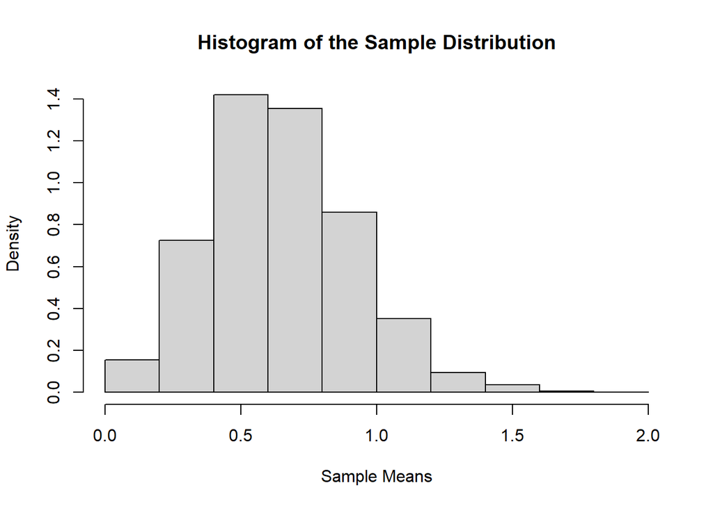

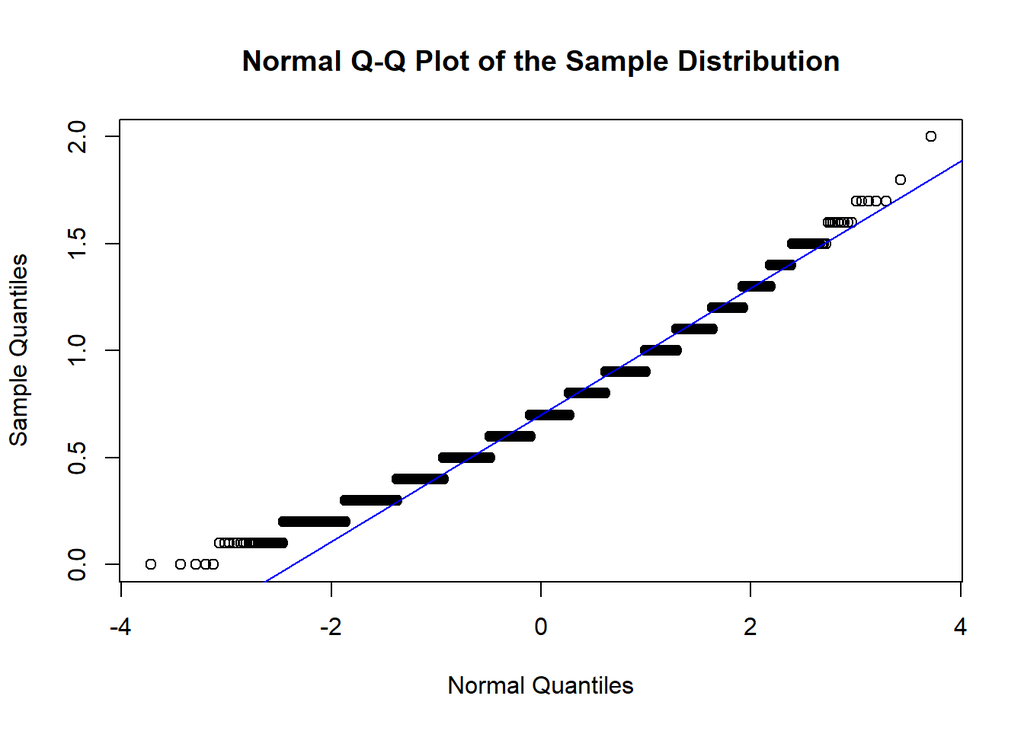

```r
poiss_clt(0.7,10,5000)
```

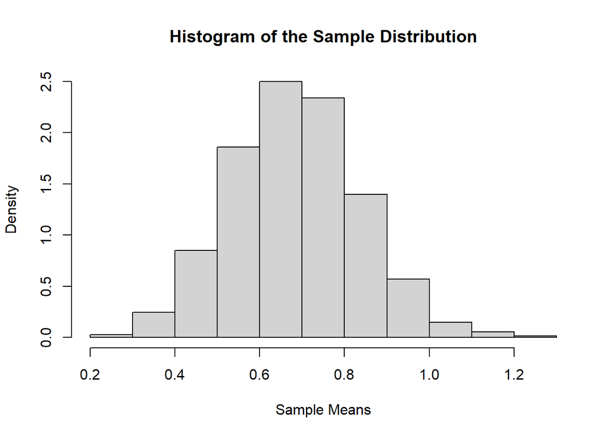

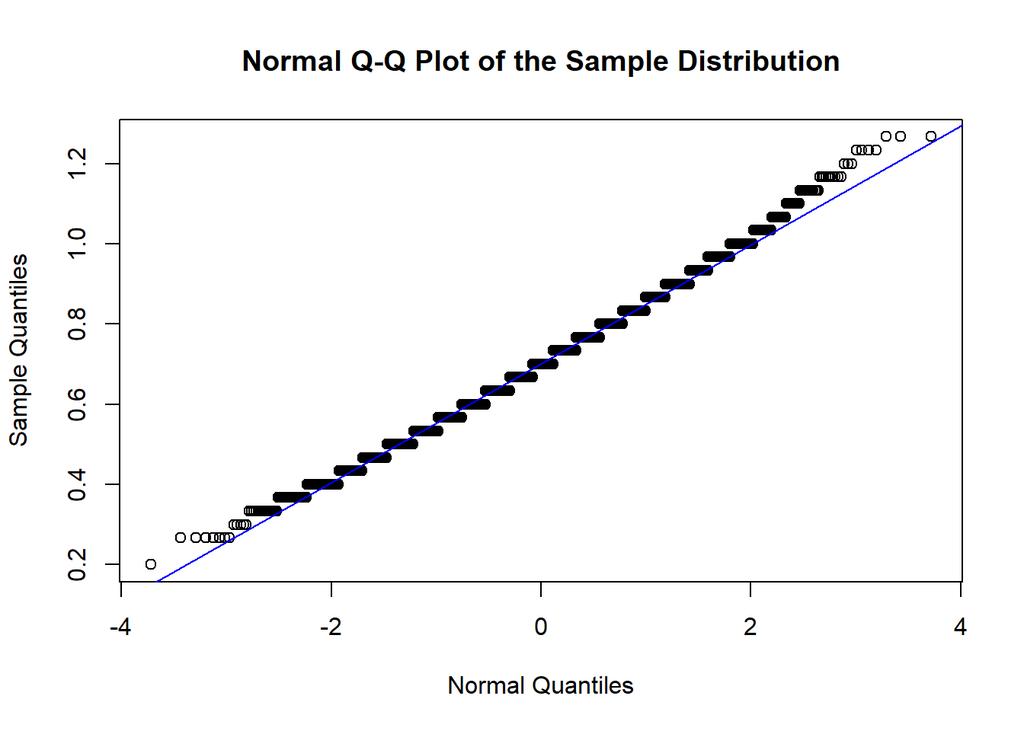

```r
poiss_clt(0.7,30,5000)
```

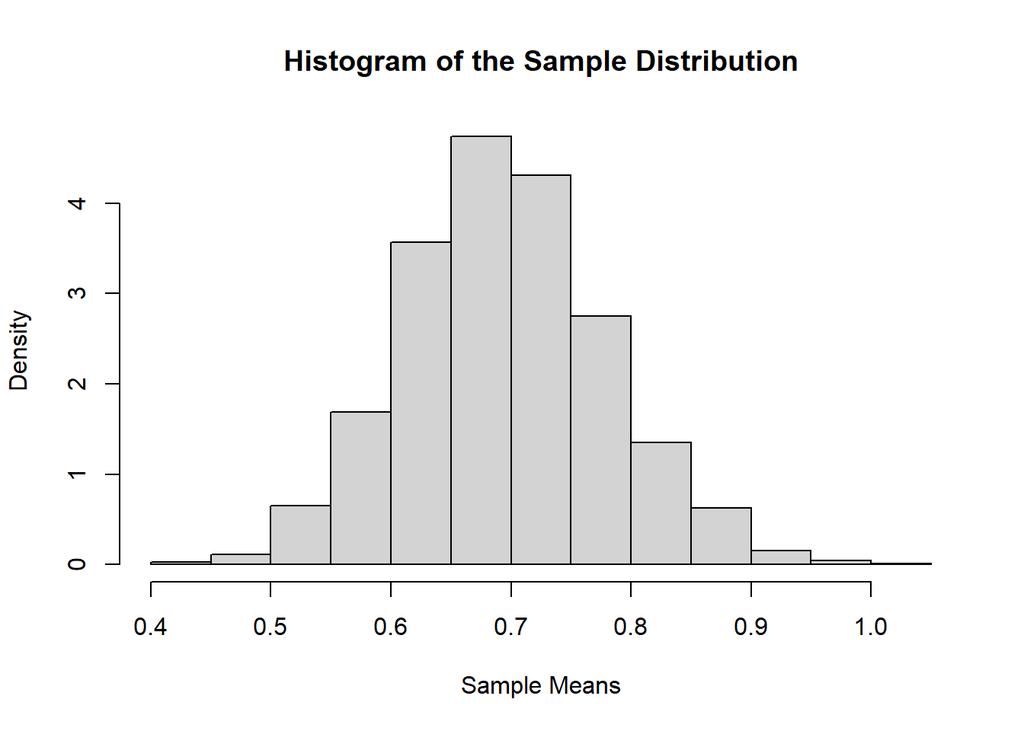

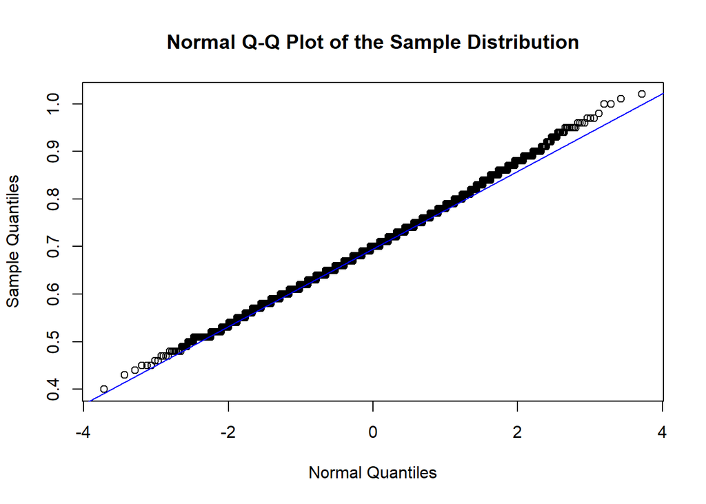

```r
poiss_clt(0.7,100,5000)
```

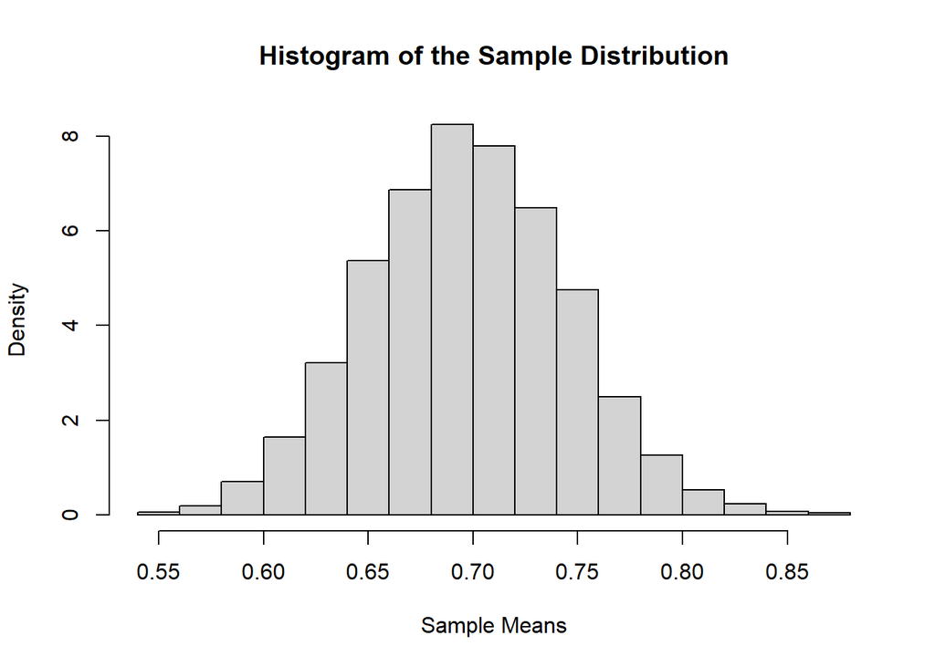

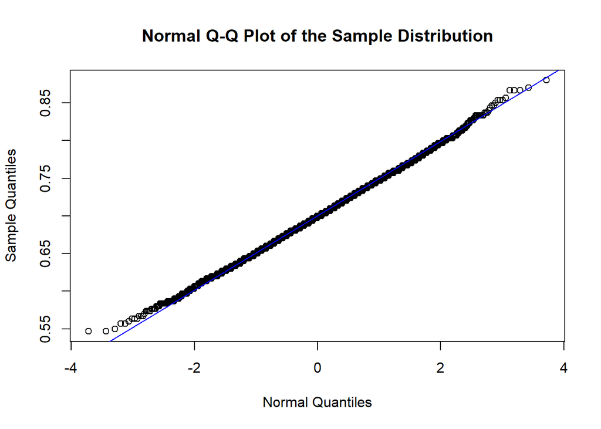

```r
poiss_clt(0.7,300,5000)
```

case 2

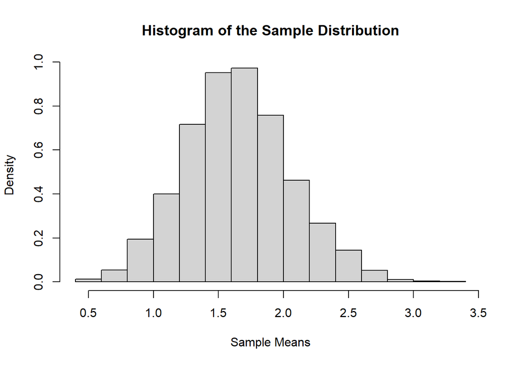

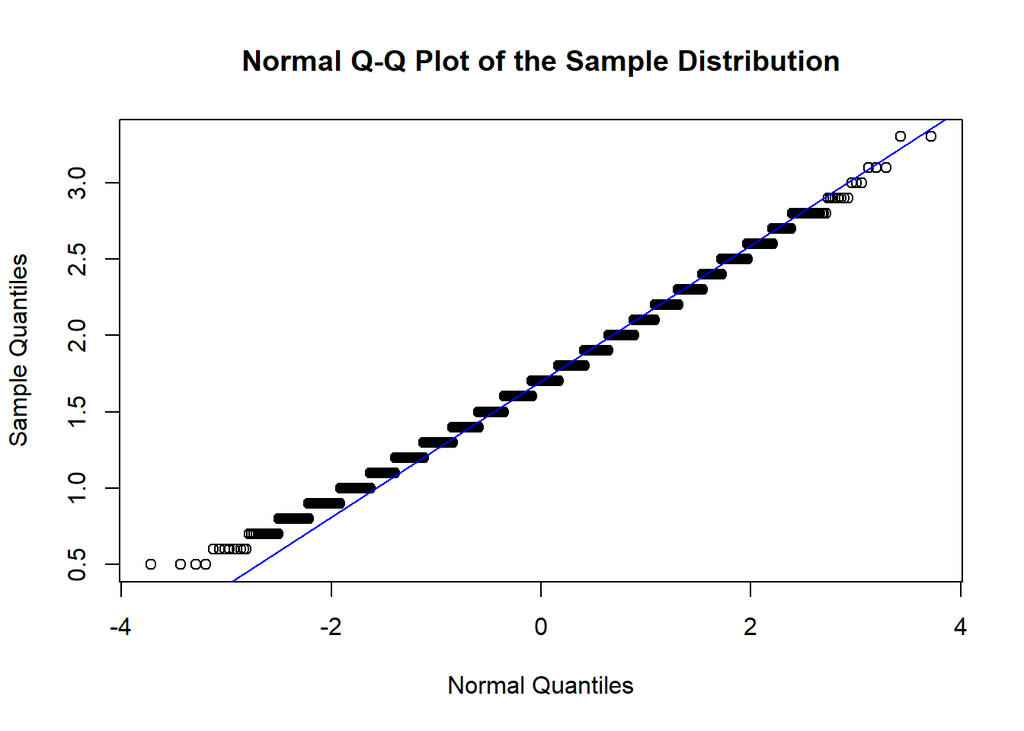

```r
poiss_clt(1.7,10,5000)
```

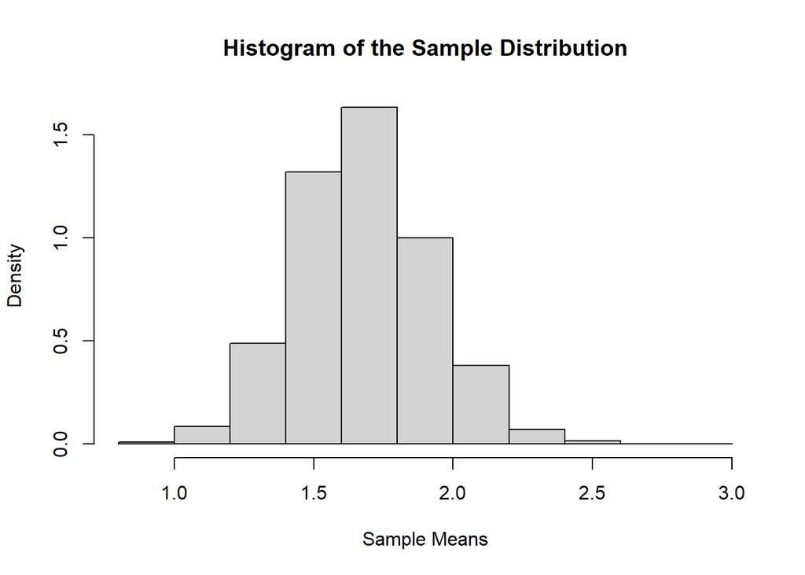

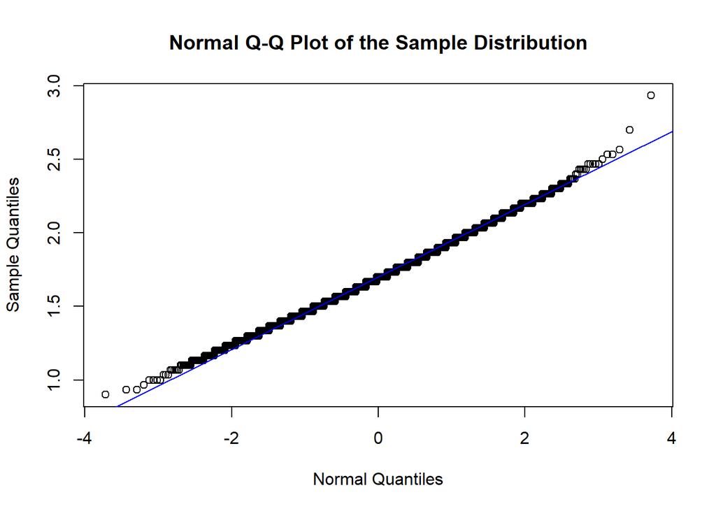

```r
poiss_clt(1.7,30,5000)
```

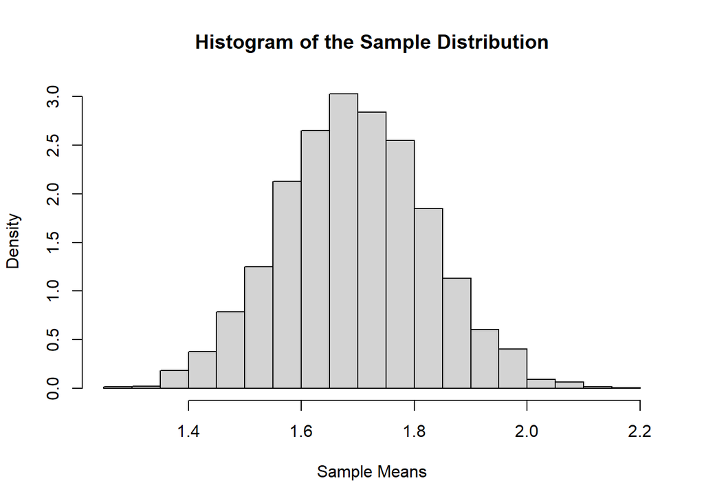

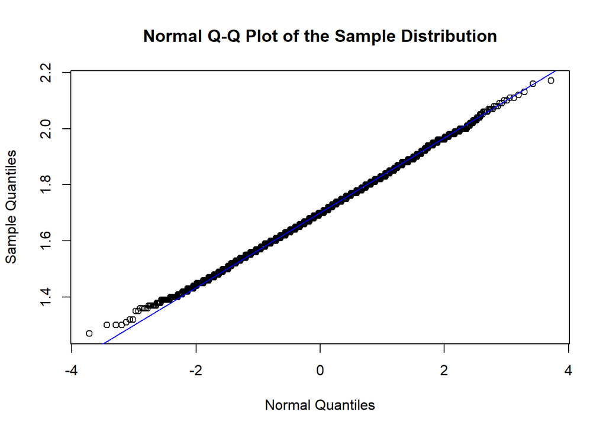

```r
poiss_clt(1.7,100,5000)
```

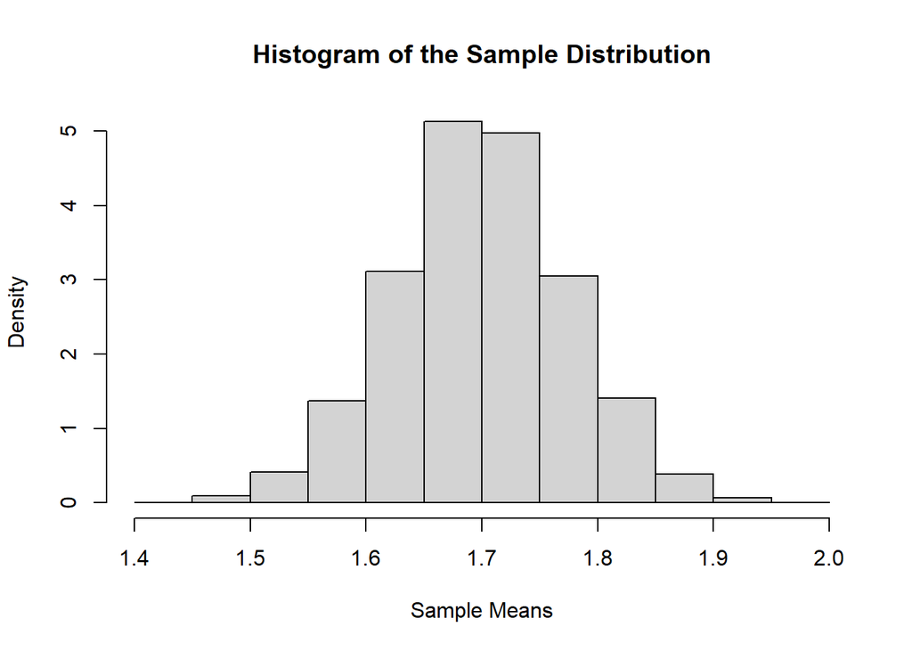

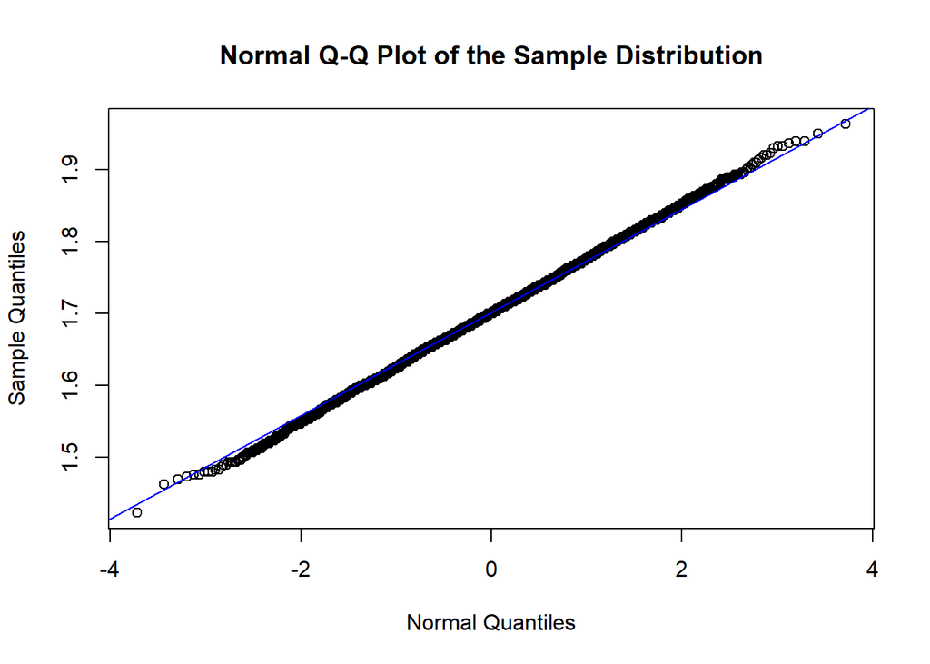

```r
poiss_clt(1.7,300,5000)
```

### **Problem 2:** (1 point)

Consider the `JohnsonJohnson` dataset. The datset contains the Quarterly earnings (dollars) per Johnson & Johnson share 1960–80.

1. Draw the time series plot of Quarterly earnings in regular scale and log-scale using the `ggplot` (1 point)

```r
head(JohnsonJohnson)
```

```
## [1] 0.71 0.63 0.85 0.44 0.61 0.69
```

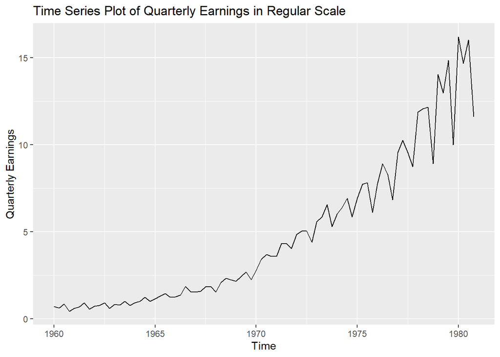

```r
library(ggplot2)
JJ_data=data.frame(cbind(quarterly_earnings=JohnsonJohnson,time=time(JohnsonJohnson)))
ggplot(JJ_data)+geom_line(aes(x=time,y=quarterly_earnings))+labs(title="Time Series Plot of Quarterly Earnings in Regular Scale",x="Time",y="Quarterly Earnings")
```

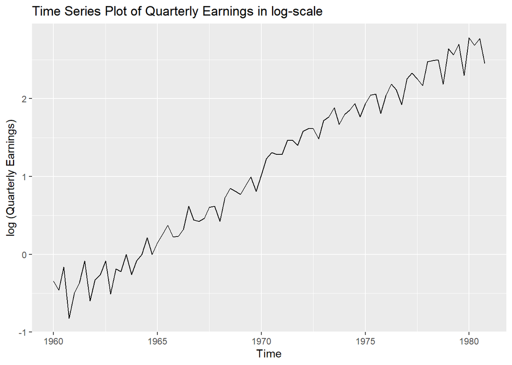

```r
ggplot(JJ_data)+geom_line(aes(x=time,y=log(quarterly_earnings)))+labs(title="Time Series Plot of Quarterly Earnings in log-scale",x="Time",y="log (Quarterly Earnings)")
```

### **Problem 3:** (2 points)

- An experiment was conducted to measure and compare the effectiveness of various feed supplements on the growth rate of chickens.
- Following R-code is a standard side-by-side boxplot showing effect of feed supplements on the growth rate of chickens.

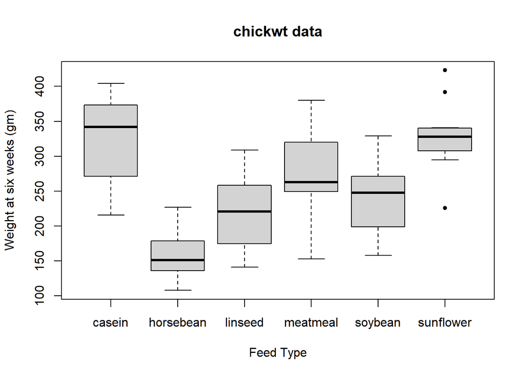

```r
boxplot(weight~feed,data=chickwts,pch=20
        ,main = "chickwt data"
        ,ylab = "Weight at six weeks (gm)"
        ,xlab = "Feed Type")
```

1. Reproduce the same plot using the `ggplot`; while fill each boxes with different colour. (1 point)
2. In addition draw probability density plot for weights of chicken’s growth by each feed seperately using the `ggplot`. Draw this plot seperately. (1 point)

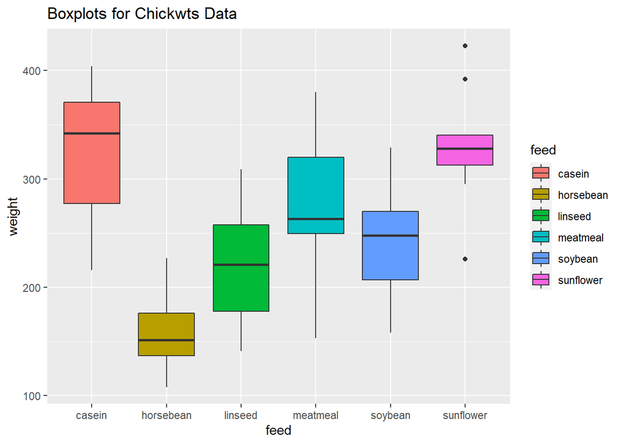

```r
library(ggplot2)
ggplot(chickwts)+geom_boxplot(mapping=aes(x=feed,y=weight,fill=feed))+labs(title="Boxplots for Chickwts Data")
```

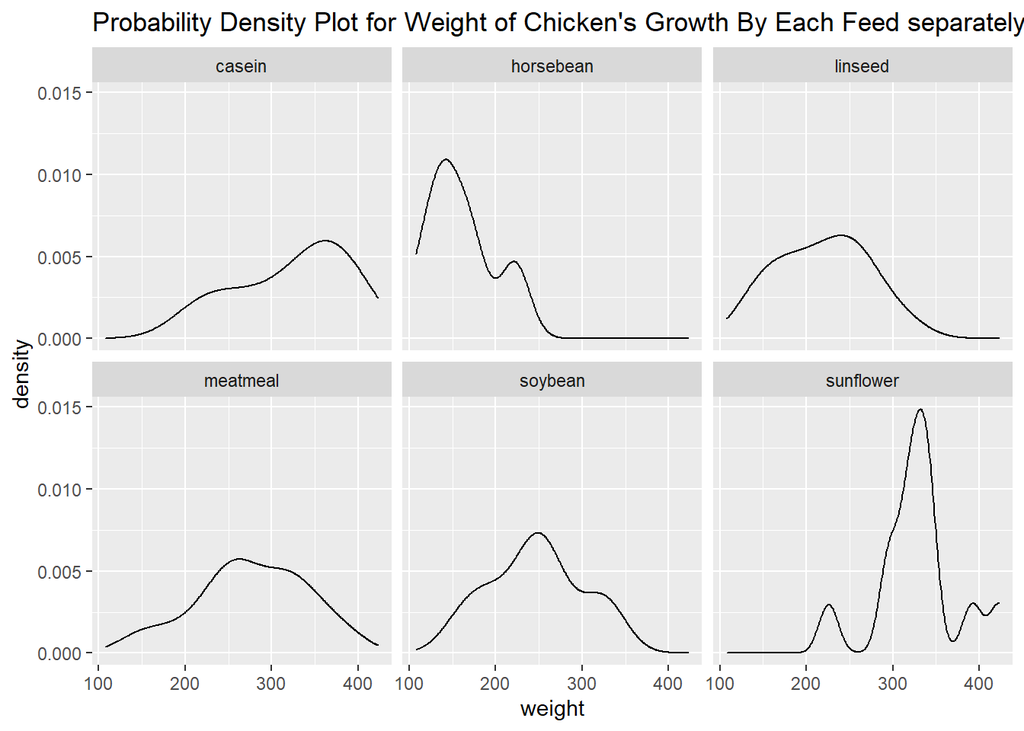

```r
ggplot(chickwts)+geom_density(aes(x=weight))+facet_wrap(.~feed)+labs(title="Probability Density Plot for Weight of Chicken's Growth By Each Feed separately")
```

### **Problem 4:** (4 points)

- Consider the monthly data on the price of frozen orange juice concentrate in the orange-growing region of Florida.
- The data is available in `FrozenJuice` dataset of the `AER` package.
- We want to compare the average of price between decade of 1980’s and 1990’s. So we split the data into two

```r
library(AER)
```

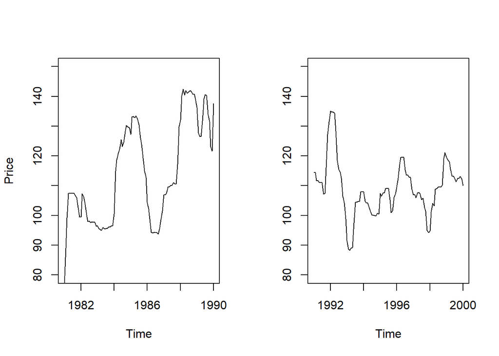

```r
data("FrozenJuice")

data_80_90=window(FrozenJuice,start=1981,end=1990)
data_90_2K=window(FrozenJuice,start=1991,end=2000)
par(mfrow=c(1,2))
plot(data_80_90[,'price'],ylim=c(80,150),ylab='Price')
plot(data_90_2K[,'price'],ylim=c(80,150),ylab='')
```

- Generally it is believed that the price of the product increases over time due to inflation effect. So we expect that the average price during 1991-2000 would be higher than the 1981-1990.

The mean and standard deviation of price is estimates as

```r
n1 = nrow(data_80_90)
cat('number of samples in 80s decade: ',n1,'\n')
```

```
## number of samples in 80s decade:  109
```

```r
m1 = mean(data_80_90[,'price'])
s1 = sd(data_80_90[,'price'])
cat('mean and sd for 80s decade','\n')
```

```
## mean and sd for 80s decade
```

```r
round(c(mean = m1,sd = s1),2)
```

```
##   mean     sd
## 114.32  16.88
```

```r
n2 = nrow(data_90_2K)
cat('number of samples in 90s decade: ',n2,'\n')
```

```
## number of samples in 90s decade:  109
```

```r
m2 = mean(data_90_2K[,'price'])
s2 = sd(data_90_2K[,'price'])
cat('mean and sd for 90s decade','\n')
```

```
## mean and sd for 90s decade
```

```r
round(c(mean = m2,sd = s2),2)
```

```
##   mean     sd
## 109.14   9.25
```

```r
round(c(mean = m2,sd = s2),2)
```

```
##   mean     sd
## 109.14   9.25
```

- The sample size for both decades are more than 100. So we can assume that CLT will kick-in.
1. If $\bar{X}_1$ and $\bar{X}_2$ are the sample mean of the price the two decades, plot the sampling distributions of sample mean for both decades on the same graph. (1 point)

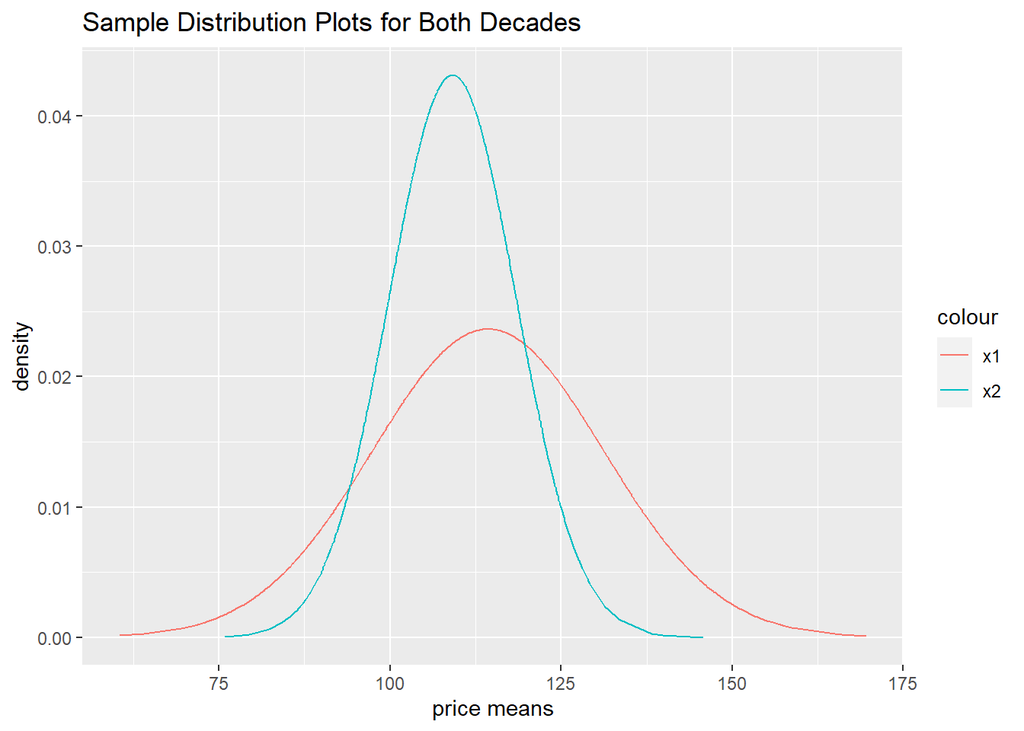

```r
library(ggplot2)
x1=sort(rnorm(1000,mean=m1,sd=s1))
density_x1=dnorm(x1,mean=m1,sd=s1)
x2=sort(rnorm(1000,mean=m2,sd=s2))
density_x2=dnorm(x2,mean=m2,sd=s2)
df=data.frame(cbind(x1,density_x1,x2,density_x2))
ggplot(df)+geom_line(aes(x=x1,y=density_x1,col="x1"))+geom_line(aes(x=x2,y=density_x2,col="x2"))+labs(x="price means",y="density",title="Sample Distribution Plots for Both Decades")
```

b) Simulate the $\bar{X}_1$ and $\bar{X}_2$ from respective sampling distribution, then calculate the difference.
$$d=\bar{X}_1-\bar{X}_2$$
Simulate $d$; `5000` times. (1 point)

```r
x1_sim=rnorm(5000,m1,s1)
x2_sim=rnorm(5000,m2,s2)
d=x1_sim-x2_sim
```

3. Calculate $P(d<0)$ as
   $$\hat{P}(d<0)=\frac{\text{number of d<0}}{5000}$$
   and draw the histogram of $d$ and marked the area where $d<0$ (1 point)

```r
#The probability d<0 is:-
p=sum(d<0)/5000
p
```

```
## [1] 0.3936
```

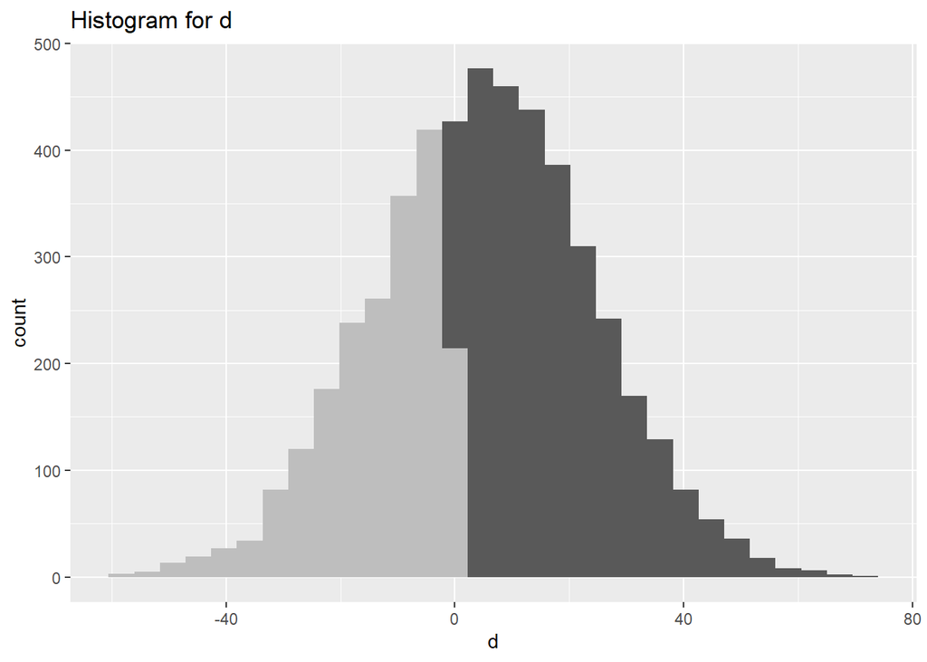

```r
df1=data.frame(d)
ggplot(df1,aes(d))+geom_histogram()+geom_histogram(data=subset(df1,d<0),fill="grey")+labs(title="Histogram for d")
```

4. Based on the analysis, what is the chance that the average price of Juice for decade 1981-90 was same or less than the decade of 1991-2000? (1 point)

```r
#Therefore based on the analysis we can say the chance that average price of Juice for decade 1981-90 was same or less than the decade of 1991-2000 is:-
p
```

```
## [1] 0.3936
```